# Analisis de encuestas elecciones 2023

Sofía Giménez Gritti

## Introducción

Dado que nos encontramos en un año electoral, con una alta demanda de análisis de encuestas, tomaremos los datos recopilados en este enlace (https://es.wikipedia.org/wiki/Anexo:Encuestas_de_intenci%C3%B3n_de_voto_para_las_elecciones_presidenciales_de_Argentina_de_2023) , de distintas encuestadoras para medir la intención de voto de los partidos relevados. La idea es poder construir una visualización válida para analizar el parorama electoral de cara a las próximas elecciones.

## Exploración de los datos

Cargamos el paquete a utilizar, en este caso, una extracción de los datos de las encuestas, con la construcicón de un csv. Observaremos las primeras filas del mismo, y recorreremos sus columnas

```r
url <- "https://github.com/DiploDatosUNAB/informe-grupo_17/raw/main/datos/encuestas_datos.csv"
encuestas <- read.csv2(url)
head(encuestas)
```

```
##       Fecha              Encuestadora Muestra Todos Juntos Libertad_Avanza
## 1  7/5/2023                     CELAG    2002  26.1   24.6            29.3
## 2 30/4/2023                     Fixer    1257  26.0   32.0            22.0
## 3 30/4/2023                   Opinaia    2000  23.0   27.0            26.0
## 4 16/4/2023 Zuban Córdoba & Asociados    1300  26.6   20.4            26.0
## 5 16/4/2023 Zuban Córdoba & Asociados      NA  28.1   24.0            22.0
## 6 16/4/2023 Zuban Córdoba & Asociados      NA  28.5   23.5            18.0
##   Consenso_Federal FIT Otros Blanco Indecisos Ventaja
## 1              6.2 3.5   6.0      1       1.7     3.2
## 2              3.0 2.0    NA      5      10.0     6.0
## 3              2.0 2.0    NA     NA      15.0     1.0
## 4              5.6 2.7    NA     NA      18.7     0.6
## 5              5.7 2.4    NA     NA      17.8     4.1
## 6              4.7 2.8   7.5     NA      14.9     5.0
```

```r
encuestas$Fecha <- as.Date(encuestas$Fecha, format = "%d/%m/%Y")
```

```r
colnames(encuestas)
```

```
##  [1] "Fecha"            "Encuestadora"     "Muestra"          "Todos"
##  [5] "Juntos"           "Libertad_Avanza"  "Consenso_Federal" "FIT"
##  [9] "Otros"            "Blanco"           "Indecisos"        "Ventaja"
```

Como podemos observar en la salida, los partidos analizados son: Todos, Juntos, Libertad_Avanza, Consenso_Federal, FIT, y también analiza Otros, Blanco, e Indecisos. A su vez posee los datos de encuestadora, muestra y fecha.

```r
str(encuestas)
```

```
## 'data.frame':    54 obs. of  12 variables:
##  $ Fecha           : Date, format: "2023-05-07" "2023-04-30" ...
##  $ Encuestadora    : chr  "CELAG" "Fixer" "Opinaia" "Zuban Córdoba & Asociados" ...
##  $ Muestra         : int  2002 1257 2000 1300 NA NA 1679 NA NA 1402 ...
##  $ Todos           : num  26.1 26 23 26.6 28.1 28.5 23.7 30 22.8 27 ...
##  $ Juntos          : num  24.6 32 27 20.4 24 23.5 26.6 29.8 28.1 27 ...
##  $ Libertad_Avanza : num  29.3 22 26 26 22 18 26.5 24.9 16.6 23 ...
##  $ Consenso_Federal: num  6.2 3 2 5.6 5.7 4.7 3.6 2.2 10.8 5 ...
##  $ FIT             : num  3.5 2 2 2.7 2.4 2.8 3.8 2.4 4.9 3 ...
##  $ Otros           : num  6 NA NA NA NA 7.5 4.5 3.7 5.4 4 ...
##  $ Blanco          : num  1 5 NA NA NA NA NA NA NA NA ...
##  $ Indecisos       : num  1.7 10 15 18.7 17.8 14.9 11.3 7.1 11.4 7 ...
##  $ Ventaja         : num  3.2 6 1 0.6 4.1 5 0.1 0.2 5.3 NA ...
```

Podemos observar que los tipos de datos son correctos para el procesamiento.

```r
datos_columnas <- apply(encuestas, 2, function(x) length(na.omit(x)))
print(datos_columnas)
```

```
##            Fecha     Encuestadora          Muestra            Todos
##               54               54               37               54
##           Juntos  Libertad_Avanza Consenso_Federal              FIT
##               54               54               33               48
##            Otros           Blanco        Indecisos          Ventaja
##               28               25               52               52
```

En el código anterior podemos ver la cantidad de datos que tiene cada columna, ignorando los nulos. Eso nos da un panorama de qué partidos o indicadores fueron los más relevados, y a su vez, observar la cantitad de datos faltantes sobre encuestadora y muestra.

```r
encuestas_alargadas <- pivot_longer(encuestas,
                                    cols = c(Todos, Juntos, Libertad_Avanza, Consenso_Federal, Indecisos),
                                    names_to = "Partido",
                                    values_to = "Intencion_voto")
encuestas_alargadas$Fecha <- as.Date(encuestas_alargadas$Fecha, format = "%d/%m/%Y")
encuestas_alargadas$Intencion_voto <- as.numeric(encuestas_alargadas$Intencion_voto)

resultados <- encuestas_alargadas %>%
  group_by(Partido) %>%
  summarise(Media = mean(Intencion_voto, na.rm = TRUE),
            Mediana = median(Intencion_voto, na.rm = TRUE),
            Minimo = min(Intencion_voto, na.rm = TRUE),
            Maximo = max(Intencion_voto, na.rm = TRUE))

print(resultados)
```

```
## # A tibble: 5 × 5
##   Partido          Media Mediana Minimo Maximo
##   <chr>            <dbl>   <dbl>  <dbl>  <dbl>
## 1 Consenso_Federal  4.79     4.8    2     10.8
## 2 Indecisos        13.3     11      1.7   33
## 3 Juntos           28.5     28.4   10     41.1
## 4 Libertad_Avanza  21.2     21.6   10.8   29.3
## 5 Todos            25.8     26.3   10     35
```

Podemos obtener distintas observaciones de los calculos estadísticos construidos (Fue modificado tras la primera entrega):

- Para poder procesarlos debimos transformar los datos y en las formulas evitar los nulos. En ese sentido, se procesaron generando una tabla para facilitar su lectura.
- Observamos que la media y la mediana de Juntos se eleva por encima de la del Frente de Todos. Como así también el máximo.
- Es una elección mulripartidaria donde los porcentajes máximos, y medios de los partidos son similares.
- Existe un altmo grado de indecisos, por lo tanto, un alto grado de desconcierto sobre el resultado.

## Hipótesis

- Existe una correlación entre resultados y fecha que genera una alta varianza entre los porcentajes obtenidos por frente.
- Existe una diferencia de encuestadora, que podría sesgar los resultados estadísticos.
- Existe una paridad entre los 3 partidos mayoritarios que se mantiene en el tiempo por lo que las encuestas no permiten predecir el ballotaje.
- Cómo fluctuan los votos entre los partidos.

# TP 2: análisis detallado

### 1) Pregunta 1: Existe una correlación entre resultados y fecha que genera una alta varianza entre los porcentajes obtenidos por frente.

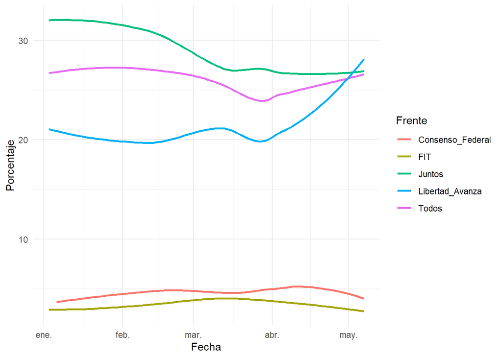

```r
ggplot(encuestas, aes(x = Fecha)) +
  geom_smooth(aes(y = Todos, color = "Todos"), se = FALSE) +
  geom_smooth(aes(y = Juntos, color = "Juntos"), se = FALSE) +
  geom_smooth(aes(y = Libertad_Avanza, color = "Libertad_Avanza"), se = FALSE) +
  geom_smooth(aes(y = Consenso_Federal, color = "Consenso_Federal"), se = FALSE) +
  geom_smooth(aes(y = FIT, color = "FIT"), se = FALSE) +
  labs(x = "Fecha", y = "Porcentaje", color = "Frente") +
  theme_minimal()
```

En el gráfico de tendencia construido, se puede observar, en referencia a la pregunta, la gran fluctuación que se dió a lo largo de este año en votos donde los dos partidos mayoritarios perdieron un gran caudal de votos que parece a ver sido redirigido a la tercera fuerza, Libertad Avanza, quién la tendencia lo marca como el primero en las últimas mediciones.

### 2) Existe una diferencia de encuestadora, que podría sesgar los resultados estadísticos.

```r
resumen <- encuestas %>%
  group_by(Encuestadora, month(Fecha)) %>%
  summarize(
    Promedio_Todos = mean(Todos),
    Desviacion_Todos = sd(Todos),
    Promedio_Juntos = mean(Juntos),
    Desviacion_Juntos = sd(Juntos),
    Promedio_Libertad_Avanza = mean(Libertad_Avanza),
    Desviacion_Libertad_Avanza = sd(Libertad_Avanza),
    Promedio_Consenso_Federal = mean(Consenso_Federal),
    Desviacion_Consenso_Federal = sd(Consenso_Federal),
    Promedio_FIT = mean(FIT),
    Desviacion_FIT = sd(FIT)
  )
resumen <- resumen[order(resumen$`month(Fecha)`), ]
tabla_formateada <- kable(resumen, format = "html", table.attr = "class='styled-table'")
tabla_formateada
```

| Encuestadora | month(Fecha) | Promedio_Todos | Desviacion_Todos | Promedio_Juntos | Desviacion_Juntos | Promedio_Libertad_Avanza | Desviacion_Libertad_Avanza | Promedio_Consenso_Federal | Desviacion_Consenso_Federal | Promedio_FIT | Desviacion_FIT |
| --- | --- | --- | --- | --- | --- | --- | --- | --- | --- | --- | --- |
| Aresco | 1 | 27.60000 | 3.1112698 | 29.05000 | 0.6363961 | 20.55000 | 2.4748737 | 5.250000 | 0.0707107 | 3.400000 | 0.8485281 |
| Federico González & Asociados | 1 | 26.25000 | 0.9192388 | 29.85000 | 0.9192388 | 21.35000 | 1.4849242 | 2.850000 | 0.0707107 | 3.550000 | 0.0707107 |
| Opinaia | 1 | 25.00000 | NA | 32.00000 | NA | 22.00000 | NA | 4.000000 | NA | 2.000000 | NA |
| Raúl Aragón & Asociados | 1 | 24.80000 | NA | 29.10000 | NA | 18.30000 | NA | NA | NA | 3.700000 | NA |
| Solmoirago | 1 | 29.20000 | 0.1414214 | 39.20000 | 2.6870058 | 18.80000 | 0.9899495 | NA | NA | 2.300000 | 0.7071068 |
| Synopsis | 1 | 29.50000 | NA | 37.70000 | NA | 21.30000 | NA | NA | NA | 2.900000 | NA |
| Zuban Córdoba & Asociados | 1 | 30.30000 | NA | 23.00000 | NA | 23.20000 | NA | 4.800000 | NA | NA | NA |
| CIGP | 2 | 25.60000 | NA | 30.80000 | NA | 10.80000 | NA | NA | NA | NA | NA |
| IPD | 2 | 27.00000 | NA | 31.00000 | NA | 18.00000 | NA | 7.000000 | NA | 5.000000 | NA |
| Management & Fit | 2 | 23.60000 | NA | 25.70000 | NA | 20.40000 | NA | NA | NA | NA | NA |
| Opina Argentina | 2 | 27.00000 | 1.0000000 | 30.66667 | 3.2145503 | 21.66667 | 2.5166115 | NA | NA | 3.666667 | 0.5773503 |
| Opinaia | 2 | 24.00000 | 0.0000000 | 29.00000 | 2.8284271 | 24.00000 | 0.0000000 | 3.500000 | 0.7071068 | 2.500000 | 0.7071068 |
| Solmoirago | 2 | 28.25000 | 2.3334524 | 35.25000 | 7.5660426 | 16.10000 | 2.6870058 | NA | NA | 2.600000 | 0.1414214 |
| Analogías | 3 | 25.20000 | NA | 24.50000 | NA | 20.70000 | NA | NA | NA | 3.500000 | NA |
| Aresco | 3 | 33.00000 | NA | 36.90000 | NA | 20.60000 | NA | NA | NA | NA | NA |
| Clivajes Consultores | 3 | 26.70000 | NA | 20.80000 | NA | 28.40000 | NA | NA | NA | NA | NA |
| Consultora Tendencias | 3 | 27.50000 | NA | 30.60000 | NA | 18.50000 | NA | 2.400000 | NA | 6.200000 | NA |
| Federico González & Asociados | 3 | 25.20000 | NA | 31.50000 | NA | 15.20000 | NA | 4.600000 | NA | 3.300000 | NA |
| Mucho en Común | 3 | 10.00000 | NA | 10.00000 | NA | 25.00000 | NA | NA | NA | 2.000000 | NA |
| Opinaia | 3 | 20.00000 | NA | 29.00000 | NA | 20.00000 | NA | 4.000000 | NA | 3.000000 | NA |
| Poliarquía | 3 | 31.00000 | 5.6568542 | 29.00000 | 5.6568542 | 23.00000 | 0.0000000 | NA | NA | 4.000000 | 1.4142136 |
| Synopsis | 3 | 23.40000 | NA | 27.40000 | NA | 14.60000 | NA | 9.200000 | NA | 5.300000 | NA |
| UdeSA | 3 | 15.00000 | NA | 23.00000 | NA | 11.00000 | NA | 5.000000 | NA | 4.000000 | NA |
| Fixer | 4 | 26.00000 | NA | 32.00000 | NA | 22.00000 | NA | 3.000000 | NA | 2.000000 | NA |
| GOP y Trespuntozero | 4 | 28.85000 | 1.6263456 | 36.30000 | 0.4242641 | 19.20000 | 0.1414214 | NA | NA | 1.150000 | 0.0707107 |
| IPD | 4 | 25.50000 | 0.7071068 | 26.00000 | 2.8284271 | 26.00000 | 1.4142136 | NA | NA | NA | NA |
| Inteligencia Analítica | 4 | 19.60000 | 1.2727922 | 23.15000 | 0.6363961 | 20.55000 | 0.3535534 | NA | NA | 5.550000 | 0.3535534 |
| Management & Fit | 4 | 26.95000 | 3.7784477 | 25.92500 | 2.5289985 | 21.55000 | 4.8397658 | 6.675000 | 0.2500000 | 4.275000 | 0.5188127 |
| Opina Argentina | 4 | 27.00000 | NA | 27.00000 | NA | 23.00000 | NA | 5.000000 | NA | 3.000000 | NA |
| Opinaia | 4 | 23.00000 | NA | 27.00000 | NA | 26.00000 | NA | 2.000000 | NA | 2.000000 | NA |
| Reale Dalla Torre | 4 | 24.25000 | 4.7376154 | 27.22500 | 5.5507882 | 23.65000 | 4.3133514 | NA | NA | 4.350000 | 0.7778175 |
| Synopsis | 4 | 25.50000 | 3.9230090 | 28.16667 | 1.6010413 | 22.66667 | 5.3144457 | 5.533333 | 4.6144700 | 3.700000 | 1.2529964 |
| Taquion | 4 | 21.40000 | NA | 30.10000 | NA | 24.30000 | NA | 4.800000 | NA | 2.500000 | NA |
| Zuban Córdoba & Asociados | 4 | 27.73333 | 1.0016653 | 22.63333 | 1.9502137 | 22.00000 | 4.0000000 | 5.333333 | 0.5507571 | 2.633333 | 0.2081666 |
| CELAG | 5 | 26.10000 | NA | 24.60000 | NA | 29.30000 | NA | 6.200000 | NA | 3.500000 | NA |

En respuesta a la pregunta, podemos ver la gran diferencia en el promedio que obtienen los partidos mes a mes según la encuestadora, permitiendonos plantear la idea de que puede existir un sesgo en base al formato de la medición.

### 3) Existe una paridad entre los 3 partidos mayoritarios que se mantiene en el tiempo por lo que las encuestas no permiten predecir el ballotaje.

```r
encuestas$Fecha <- as.Date(encuestas$Fecha, format = "%d/%m/%Y")
encuestas$Mes <- format(encuestas$Fecha, "%Y-%m")
promedio_mes <- encuestas %>%
  group_by(Mes) %>%
  summarise(
    Promedio_Todos = mean(Todos),
    Promedio_Juntos = mean(Juntos),
    Promedio_Libertad_Avanza = mean(Libertad_Avanza)
  )
print(promedio_mes)
```

```
## # A tibble: 5 × 4
##   Mes     Promedio_Todos Promedio_Juntos Promedio_Libertad_Avanza
##   <chr>            <dbl>           <dbl>                    <dbl>
## 1 2023-01           27.6            31.8                     20.6
## 2 2023-02           26.2            30.8                     19.4
## 3 2023-03           24.4            26.5                     20
## 4 2023-04           25.5            27.2                     22.5
## 5 2023-05           26.1            24.6                     29.3
```

Como se puede observar, según las encuestas relevadas, se espera una elección de 3 tercios, por lo que es imposible determinar cuáles van a ser participes del ballotaje según este resultado. Claramente, si se mantienen estos datos, si se puede garantizar la probabilidad de un ballotaje porque ninguno cumple los requisitos de mayoría absoluta relativa para obtener resultados en primera vuelta.

### 4) Cómo fluctúan los votos en los partidos.

```r
encuestas$Fecha <- as.Date(encuestas$Fecha, format = "%d/%m/%Y")
encuestas$Mes <- format(encuestas$Fecha, "%Y-%m")
encuestas_sin_nulos <- encuestas[complete.cases(encuestas$Todos), ]
intervalos_confianza <- encuestas_sin_nulos %>%
  group_by(Mes) %>%
  summarise(
    Promedio_Todos = mean(Todos),
    Promedio_Juntos = mean(Juntos),
    Promedio_Libertad_Avanza = mean(Libertad_Avanza),
    IC_Todos = ifelse(n() > 1, paste0("[", formatC(t.test(Todos)$conf.int[1], format = "f", digits = 2), " - ", formatC(t.test(Todos)$conf.int[2], format = "f", digits = 2), "]"), "N/A"),
    IC_Juntos = ifelse(n() > 1, paste0("[", formatC(t.test(Juntos)$conf.int[1], format = "f", digits = 2), " - ", formatC(t.test(Juntos)$conf.int[2], format = "f", digits = 2), "]"), "N/A"),
    IC_Libertad_Avanza = ifelse(n() > 1, paste0("[", formatC(t.test(Libertad_Avanza)$conf.int[1], format = "f", digits = 2), " - ", formatC(t.test(Libertad_Avanza)$conf.int[2], format = "f", digits = 2), "]"), "N/A")
  )

tabla_intervalos_confianza <- data.frame(
  Mes = intervalos_confianza$Mes,
  Promedio_Todos = intervalos_confianza$Promedio_Todos,
  IC_Todos = intervalos_confianza$IC_Todos,
  Promedio_Juntos = intervalos_confianza$Promedio_Juntos,
  IC_Juntos = intervalos_confianza$IC_Juntos,
  Promedio_Libertad_Avanza = intervalos_confianza$Promedio_Libertad_Avanza,
  IC_Libertad_Avanza = intervalos_confianza$IC_Libertad_Avanza
)

print(tabla_intervalos_confianza)
```

```
##       Mes Promedio_Todos        IC_Todos Promedio_Juntos       IC_Juntos
## 1 2023-01       27.57000 [25.97 - 29.17]        31.80000 [27.95 - 35.65]
## 2 2023-02       26.17000 [24.76 - 27.58]        30.80000 [27.80 - 33.80]
## 3 2023-03       24.36364 [19.49 - 29.23]        26.51818 [21.66 - 31.37]
## 4 2023-04       25.51364 [23.99 - 27.03]        27.16136 [25.29 - 29.04]
## 5 2023-05       26.10000             N/A        24.60000             N/A
##   Promedio_Libertad_Avanza IC_Libertad_Avanza
## 1                 20.62000    [19.28 - 21.96]
## 2                 19.44000    [16.27 - 22.61]
## 3                 20.00000    [16.64 - 23.36]
## 4                 22.46818    [20.92 - 24.02]
## 5                 29.30000                N/A
```

En la tabla se construyó el intervalo de confianza de los partidos por mes, allí podemos ver la fluctuación de votos más clara que en la anterior, y en términos específicos viendo los intervalos, determinar las diferencias entre los tres partidos mayoritarios. Dada la variabilidad antes dicha, existe una gran amplitud en los intervalos de confianza fijados al 95%) por lo que la fluctuación de votos es dificil de dictaminar. Si se puede ver una mayor pedidada de votos de Juntos a favor de Libertad Avanza.